# RNA-Seq Group Project

Author

Test Student

Published

May 26, 2026

## 3 Quick Start

### 3.1 Install Quarto

```r
install.packages("quarto")
```

### 3.2 Initialize a new Quarto (`qmd`) script

To minimize typing, it can be helful to start with a Quarto template ([here](https://girke.bioinformatics.ucr.edu/GEN242/tutorials/quarto/quarto_index.html#metadata-section)) and then modify it as needed. Note the file name of a Quarto scirpt needs to have the extension `.qmd`. The template files for the following exercises are available here:

- Quarto sample script: [`sample.qmd`](https://raw.githubusercontent.com/tgirke/GEN242/refs/heads/main/tutorials/quarto/sample.qmd)
- Bibtex file for handling citations and reference section: [`bibtex.bib`](https://raw.githubusercontent.com/tgirke/GEN242/refs/heads/main/tutorials/quarto/bibtex.bib)

Users want to download these files, open the `sample.qmd` file with their preferred R IDE (*e.g.* RStudio, Nvim-R-Tmux or emacs), initilize an R session and then direct their R session to the location of these two files.

### 3.3 Metadata section

The metadata section (YAML header) in an Quarto script defines how it will be processed and rendered. The metadata section also includes both title, author, and date information as well as options for customizing the output format. For instance, PDF and HTML output can be defined with `pdf_document` and `html_document`, respectively.

```
---
title: "Project Report Title"
author: "First Last"
date: last-modified
format:
  html:
    theme: cosmo # also try flatly or lumen
    toc: true
    toc-depth: 3
    toc-location: left
    number-sections: true
    code-fold: false
    code-tools: true
    fig-cap-location: bottom
    df-print: kable
embed-resources: true
bibliography: bibtex.bib
---
```

### 3.4 Render `qmd` script

A Quarto script can be evaluated and rendered with the following `quarto_render` command or by pressing the `knit` button in RStudio. The `output_format` argument defines the format of the output.

```r
quarto::quarto_render("sample.qmd")                        # default format from YAML
quarto::quarto_render("sample.qmd", output_format="pdf")
```

```bash
quarto render sample.qmd
quarto render sample.qmd --to pdf
```

### 3.5 R code chunks

R Code Chunks can be embedded in a Quarto script by using three backticks at the beginning of a new line along with arguments in the following lines starting with `#|` that control the behavior of the code. The following lines contain the plain R code. A code chunk is terminated by a new line starting with three backticks.

````
```{r code_chunk_name}
#| eval: false
x <- 1:10
```
````

The most important chunk options are:

- `eval: true/false` — execute the chunk
- `echo: true/false` — show the source code in the output
- `warning: false` — suppress warnings
- `message: false` — suppress messages
- `cache: true` — cache results to speed up re-rendering
- `fig-height: 4` — figure height in inches
- `fig-width: 6` — figure width in inches
- `fig-cap: "..."` — figure caption
- `label: fig-name` — chunk label for cross-referencing (must start with `fig-` for figures)

For more details on chunk caching see the [knitr cache documentation](https://bookdown.org/yihui/rmarkdown-cookbook/cache.html).

### 3.6 Learning Markdown

Quarto uses standard Markdown for prose. The syntax is minimal and easy to learn:

- [Quarto Markdown Basics](https://quarto.org/docs/authoring/markdown-basics.html)
- [Markdown Intro on GitHub](https://guides.github.com/features/mastering-markdown/)
- [Markdown Cheat Sheet](https://github.com/adam-p/markdown-here/wiki/Markdown-Cheatsheet)
- [Quarto cheatsheet](https://rstudio.github.io/cheatsheets/quarto.pdf)

### 3.7 Tables

There are several ways to render tables. First, they can be printed within the R code chunks. Second, much nicer formatted tables can be generated with the functions `kable`, `kableExtra`, `pander` or `xtable`. The following example uses `kable` from the `knitr` package.

### 3.8 With `knitr::kable`

```r
library(knitr)
kable(iris[1:12,])
```

| Sepal.Length | Sepal.Width | Petal.Length | Petal.Width | Species |
| --- | --- | --- | --- | --- |
| 5.1 | 3.5 | 1.4 | 0.2 | setosa |
| 4.9 | 3.0 | 1.4 | 0.2 | setosa |
| 4.7 | 3.2 | 1.3 | 0.2 | setosa |
| 4.6 | 3.1 | 1.5 | 0.2 | setosa |
| 5.0 | 3.6 | 1.4 | 0.2 | setosa |
| 5.4 | 3.9 | 1.7 | 0.4 | setosa |
| 4.6 | 3.4 | 1.4 | 0.3 | setosa |
| 5.0 | 3.4 | 1.5 | 0.2 | setosa |
| 4.4 | 2.9 | 1.4 | 0.2 | setosa |
| 4.9 | 3.1 | 1.5 | 0.1 | setosa |
| 5.4 | 3.7 | 1.5 | 0.2 | setosa |
| 4.8 | 3.4 | 1.6 | 0.2 | setosa |

A much more elegant and powerful solution is to create fully interactive tables with the [`DT` package](https://rstudio.github.io/DT/). This JavaScirpt based environment provides a wrapper to the `DataTables` library using jQuery. The resulting tables can be sorted, queried and resized by the user. Note, Quarto source files containing JavaScript components can only be rendered into HTML and not PDF.

### 3.9 With `DT::datatable`

```r
library(DT)
datatable(iris)
```

|  | Sepal.Length | Sepal.Width | Petal.Length | Petal.Width | Species |
| --- | --- | --- | --- | --- | --- |
| 1 | 5.1 | 3.5 | 1.4 | 0.2 | setosa |
| 2 | 4.9 | 3 | 1.4 | 0.2 | setosa |
| 3 | 4.7 | 3.2 | 1.3 | 0.2 | setosa |
| 4 | 4.6 | 3.1 | 1.5 | 0.2 | setosa |
| 5 | 5 | 3.6 | 1.4 | 0.2 | setosa |
| 6 | 5.4 | 3.9 | 1.7 | 0.4 | setosa |
| 7 | 4.6 | 3.4 | 1.4 | 0.3 | setosa |
| 8 | 5 | 3.4 | 1.5 | 0.2 | setosa |
| 9 | 4.4 | 2.9 | 1.4 | 0.2 | setosa |
| 10 | 4.9 | 3.1 | 1.5 | 0.1 | setosa |

[output cut: 140 more lines]

### 3.10 Figures

Plots generated by the R code chunks in a Quarto document can be automatically inserted in the output file. The size of the figure can be controlled with the `fig.height` and `fig.width` arguments.

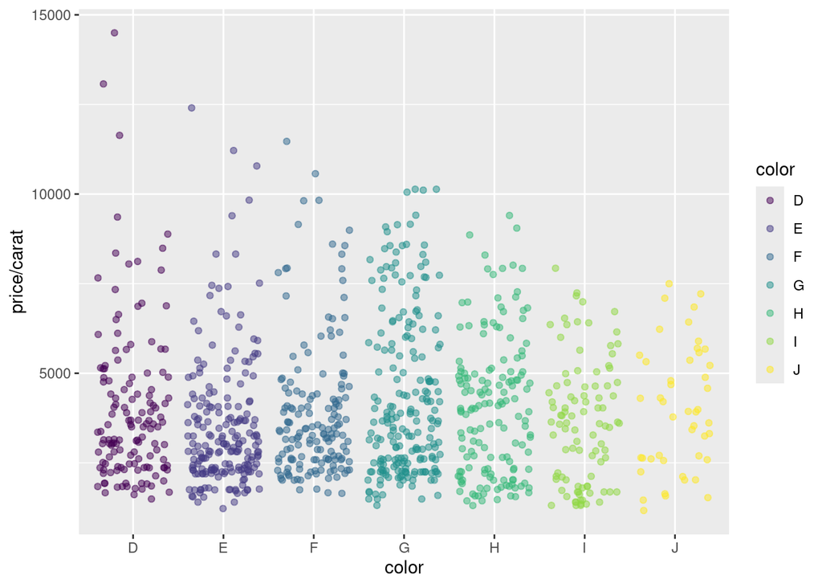

```r
library(ggplot2)
dsmall <- diamonds[sample(nrow(diamonds), 1000), ]
ggplot(dsmall, aes(color, price/carat)) + geom_jitter(alpha = I(1 / 2), aes(color=color))
```

Sometimes it can be useful to explicitly write an image to a file and then insert that image into the final document by referencing its file name in the R Markdown source. For instance, this can be useful for time consuming analyses. The following code will generate a file named `myplot.png`. To insert the file in the final document, one can use standard Markdown or HTML syntax, *e.g.*: `<img src="myplot.png"/>`.

```r
png("myplot.png")
ggplot(dsmall, aes(color, price/carat)) + geom_jitter(alpha = I(1 / 2), aes(color=color))
dev.off()
```

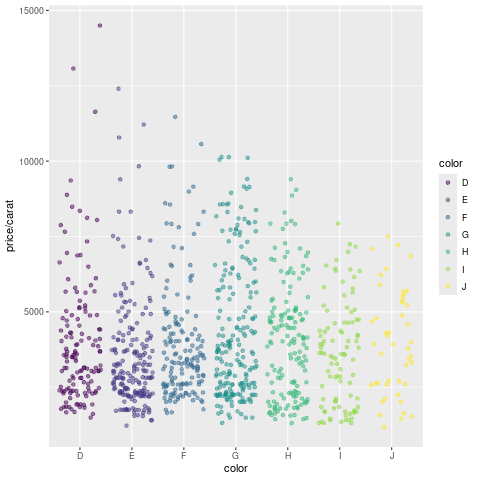

Quarto has a native cross-referencing system. This works as follows: give a chunk a label starting with `fig-` and add a caption; then reference it anywhere in the document with `@fig-label`, which renders as a numbered hyperlink, here Figure 1. This name-based referencing scheme applies to tables (`tbl-` prefix) and sections (`sec-` prefix, requires `number-sections: true`). Before this extremely useful feature was only available in LaTeX (missing in R Markdown). Also note: for large documents, like PhD theses, where referencing of figures and tables across documents is important, this feature is best supported in [Quarto Books](https://quarto.org/docs/books/). In this context it is also useful to know that Quarto documents can be converted to `tex` (LaTeX) files.

````
```{r}
#| label: fig-jitter # Note: when label is used, omit name in header line!
#| fig-cap: "Diamond price by color."
#| fig-height: 4
ggplot(dsmall, aes(color, price/carat)) +
  geom_jitter(alpha = 0.5, aes(color = color))
```
````

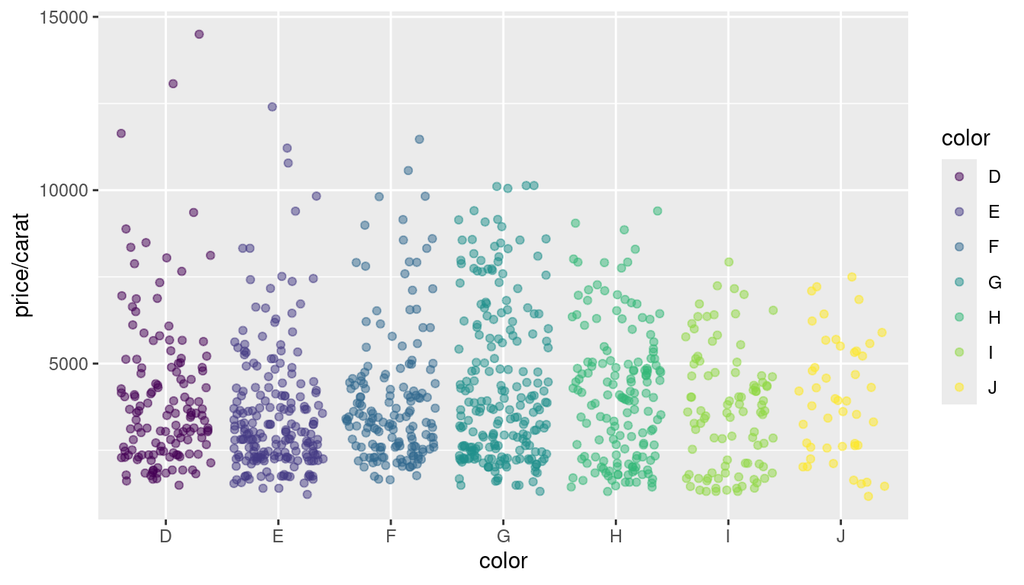

Figure 1: Diamond price by color.

```r
ggplot(dsmall, aes(color, price/carat)) +
  geom_jitter(alpha = 0.5, aes(color = color))
```

### 3.11 Custom functions

Custom functions can be kept in a separate R file (here [`custom_Fct.R`](https://raw.githubusercontent.com/tgirke/GEN242/main/content/en/tutorials/rmarkdown/custom_Fct.R)) and then imported with the `source()` command. In the following example, the `custom_Fct.R` file is located on GitHub.

```r
source("https://raw.githubusercontent.com/tgirke/GEN242/refs/heads/main/tutorials/quarto/custom_Fct.R")
```

Now the imported function (here `myMAcomp`) can be used.

```r
myMA <- matrix(rnorm(100000), 10000, 10, dimnames=list(1:10000, paste("C", 1:10, sep="")))
resultDF <- myMAcomp(myMA=myMA, group=c(1,1,1,2,2,2,3,3,4,4), myfct=mean)
kable(resultDF[1:12,])
```

| C1_C2_C3 | C4_C5_C6 | C7_C8 | C9_C10 |
| --- | --- | --- | --- |
| -0.6577742 | -0.4844438 | -0.7168345 | -0.5340285 |
| -0.4182760 | 0.5702929 | -1.4095013 | 1.7527619 |
| 0.8028000 | 0.2377491 | -1.0702049 | 0.0781755 |
| 0.3678693 | 0.0744966 | 0.5900254 | 0.2711576 |
| 0.1524386 | -0.1799239 | -0.0395219 | -0.5647715 |
| 1.2141042 | 0.0823228 | 0.0345833 | -1.6556333 |
| -1.2795792 | 0.0385467 | -0.4066640 | 1.1999114 |
| -0.4979990 | -0.8429021 | -1.3144363 | 0.6862674 |
| 0.6721657 | 0.2245629 | -0.1091127 | -0.2879019 |
| -0.0514790 | 0.0360448 | -0.6577910 | 0.0766389 |
| -0.2707473 | -0.5924650 | 1.0516145 | 0.5946032 |
| 0.5592322 | -0.1852662 | 0.8643128 | 0.7688194 |

### 3.12 Inline R code

To evaluate R code inline, one can enclose an R expression with a single back-tick followed by `r` and then the actual expression. For instance, the back-ticked version of ‘r 1 + 1’ evaluates to 2 and ‘r pi’ evaluates to 3.1415927.

### 3.13 Mathematical equations

To render mathematical equations, one can use standard Latex syntax. When expressions are enclosed with single `$` signs then they will be shown inline, while enclosing them with double `$$` signs will show them in display mode. For instance, the following Latex syntax `d(X,Y) = \sqrt[]{ \sum_{i=1}^{n}{(x_{i}-y_{i})^2} }` renders in display mode as follows:

$$d(X,Y) = \sqrt[]{ \sum_{i=1}^{n}{(x_{i}-y_{i})^2} }$$

To learn LaTeX syntax for mathematical equations, one can consult various online manuals, such as this [Wikibooks tutorial](https://en.wikibooks.org/wiki/LaTeX/Mathematics), or use an online equation rendering and checking tool, such as this [one](https://arachnoid.com/latex/).

### 3.14 Citations and bibliographies

Citations and bibliographies can be autogenerated in Quarto in a similar way as in Latex/Bibtex. Reference collections should be stored in a separate file in Bibtex or other supported formats. To cite a publication in a Quarto script, one uses the syntax `[@<id1>]` where `<id1>` needs to be replaced with a reference identifier present in the Bibtex database listed in the metadata section of the Quarto script (*e.g.* `bibtex.bib`). For instance, to cite Lawrence et al. (2013), one uses its reference identifier (*e.g.* `Lawrence2013-kt`) as `<id1>` (Lawrence et al. 2013). This will place the citation inline in the text and add the corresponding reference to a reference list at the end of the output document. For the latter a special section called `References` needs to be specified at the end of the R Markdown script. To fine control the formatting of citations and reference lists, users want to consult this [R Markdown page](http://rmarkdown.rstudio.com/authoring_bibliographies_and_citations.html). Also, for general reference management and obtaining references in Bibtex format [Paperpile](https://paperpile.com/features) can be very helpful.

### 3.15 Viewing Quarto reports on HPCC cluster

Quarto reports located on UCR’s HPCC Cluster can be viewed locally in a web browser (without moving the source HTML) by creating a symbolic link from a user’s `.html` directory. This way any updates to the report will show up immediately without creating another copy of the HTML file. For instance, if user `ttest` has generated an Quarto report under `~/bigdata/today/rmarkdown/sample.html`, then the symbolic link can be created as follows:

```r
cd ~/.html
ln -s ~/bigdata/today/rmarkdown/sample.html sample.html
```

After this one can view the report in a web browser using this URL https://cluster.hpcc.ucr.edu/~ttest/rmarkdown/sample.html. If necessary access to the URL can be restricted with a password following the instructions [here](http://hpcc.ucr.edu/manuals_linux-cluster_sharing.html#sharing-files-on-the-web).

### 3.16 Viewing Quarto report on GitHub

To host and view static HTML files on GitHub, follow the instructions [here](https://girke.bioinformatics.ucr.edu/GEN242/tutorials/github/github.html#viewing-static-html-files-on-github). Note, this works only with public GitHub repos.

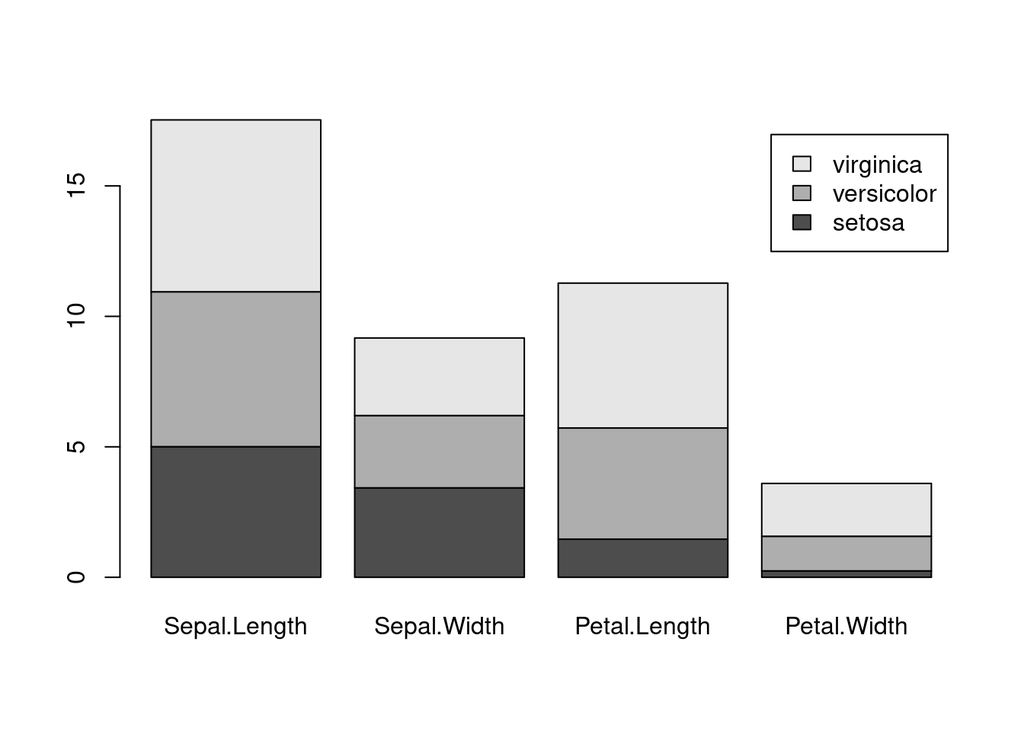

```r
mMA <- sapply(colnames(iris[,1:4]), function(x) tapply(iris[,x], iris[,5], mean))
barplot(mMA, beside=FALSE, legend=rownames(mMA))
```

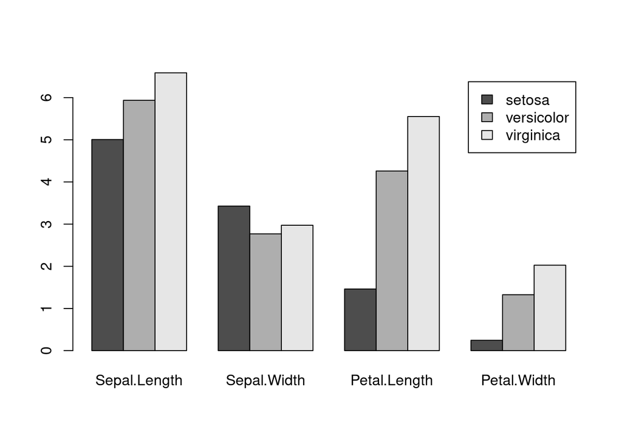

```r
barplot(mMA, beside=TRUE, legend=rownames(mMA))
```

## 5 References

Lawrence, Michael, Wolfgang Huber, Hervé Pagès, et al. 2013. “Software for Computing and Annotating Genomic Ranges.” *PLoS Comput. Biol.* 9 (8): e1003118. https://doi.org/10.1371/journal.pcbi.1003118.

Zhang, Y, T Liu, C A Meyer, et al. 2008. “Model-Based Analysis of ChIP-Seq (MACS).” *Genome Biol.* 9 (9). https://doi.org/10.1186/gb-2008-9-9-r137.